# BellaBeat Case Study

Anh Tran

May 2021

## 1. Introduction

Bellabeat is a high-tech manufacturer of health-focused product for women. Their products which provide users with health data related to physical activity, sleep, weight, hear rate can essentially help users better understanding their habits and thus can make the change to a better healthy life.

TO promote their products and reveal substantial opportunities for growth, the company aims to gain insight into how people are already used smart devices to keep track of their daily activities. However, due to the lack of their own data for analysis, public data from FitBit Fitness Tracker Data has been used instead. The FitBit dataset included all essential information of physical activities, heart rates, weight, and sleep bahaviors of totally 33 users.

To analyze those data, R has been used. With a reasonable size of the dataset of 1,000 rows and 13 columns approximately, Excel with Power Query or SQL were also used for this case study. However, only the analysis process using R is included in this report.

## 2. Collecting Data

Dataset of FitBit Fitness Tracker Data were downloaded from [here](https://www.kaggle.com/arashnic/fitbit). All the .csv files were unzip and stored in working directory.

## 3. Wrangling Data

#### 3.1 Setting up environment

- tidyverse for data import, wrangling, and for visualization
- libridate for date functions
- reshape for data frame

#### 3.2 Importing Data

- Import the dataset using function **read.csv()**. In this study, 2 dataframes were used: dailyActivity and sleepDay.

```r
dailyActivity <- read.csv("dailyActivity_merged.csv")
sleepDay <- read.csv("sleepDay_merged.csv")
```

#### 3.3 Cleaning Data

- Check datatype of all columns using **str()** to ensure the connection and consistence between datasets. It is observed that dataframes connect by Id. Therefore, the numbers of Id in each dataframe are checked.

```r
n_distinct(dailyActivity$Id)
```

```
## [1] 33
```

```r
n_distinct(sleepDay$Id)
```

```
## [1] 24
```

- NA values are checked as well

```r
sum(is.na(dailyActivity))
```

```
## [1] 0
```

```r
sum(is.na(sleepDay))
```

```
## [1] 0
```

- The column ActivityDate in dailyActivityvand sleepDay in sleepday dataframes are change to the same name Date with a Date type.

```r
dailyActivity$Date <- as.Date(as.character(dailyActivity$ActivityDate), "%m/%d/%Y")
sleepDay$Date <- as.Date(as.character(sleepDay$SleepDay), "%m/%d/%Y")
dailyActivity <- select(dailyActivity, Id, Date, TotalSteps, TotalDistance,VeryActiveMinutes, FairlyActiveMinutes, LightlyActiveMinutes, SedentaryMinutes, Calories )
sleepDay <- select(sleepDay, Id, Date, TotalMinutesAsleep, TotalTimeInBed)
```

- Merge files using outer join with common Id and Date

```r
combined_data <- merge(dailyActivity, sleepDay, by=c("Id", "Date"), all=TRUE)
nrow(combined_data)
```

```
## [1] 943
```

```r
n_distinct(combined_data$Id)
```

```
## [1] 33
```

## 4. Conducting Descriptive Anaysis

#### 4.1 Classification of Activet type by number of steps

- Physical activities are classified using number of steps per day. For instance, - steps < 5,000: **Sedentary** - 5,000 <= steps < 7,500: **Lightly Active** - 7,500 <= steps < 10,000: **Moderately Active** - steps >= 10,000: **Very Active**

```r
data_by_active_type <- combined_data %>%
   summarise(
      active_type = factor(case_when(
         TotalSteps < 5000 ~ "Sedentary",
         TotalSteps >= 5000 &  TotalSteps < 7500 ~ "Lightly Active",
         TotalSteps >= 7500 &  TotalSteps < 10000 ~ "Moderately Active",
         TotalSteps >= 10000 ~ "Very Active",
      ),levels=c("Sedentary", "Lightly Active", "Moderately Active", "Very Active")), Calories, TotalMinutesAsleep, .group = Id) %>%
   drop_na()
```

#### 4.2 Distribution of **Active Type**

- It is observed that there are about 40% of Very Active type user, followed by 23% of Sedentary-type user, and around 18% of each type of Lightly and Moderately Users.

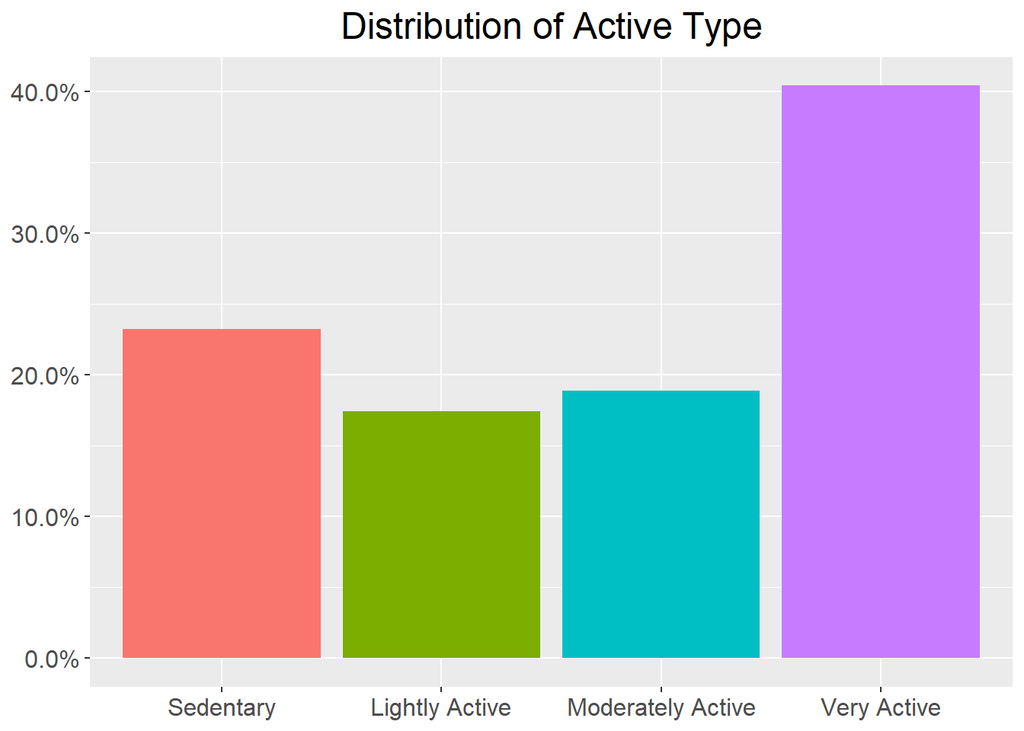

```r
data_by_active_type %>%
   group_by(active_type) %>%
   summarise(total = n()) %>%
   mutate(totals = sum(total)) %>%
   group_by(active_type) %>%
   summarise(total_percent = total / totals) %>%
   ggplot() + geom_col(mapping = aes(active_type,y=total_percent, fill=active_type)) +
   scale_y_continuous(labels = scales::percent) +
   theme(legend.position="none") +
   labs(title="Distribution of Active Type", x=NULL, y=NULL) +
   theme(legend.position="none", text = element_text(size = 15),plot.title = element_text(hjust = 0.5))
```

#### 4.3 Correlation between **Physical Activity** and **Calories** burnt

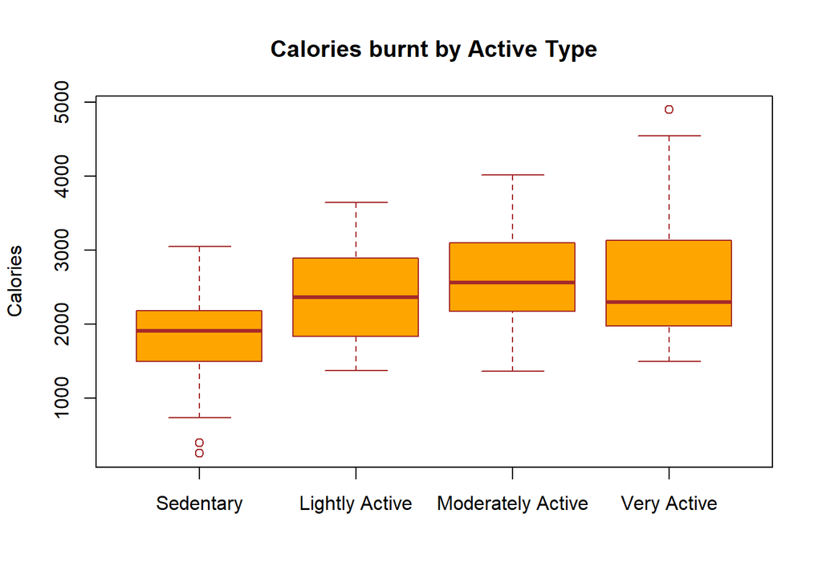

```r
boxplot(Calories~active_type,
        data=data_by_active_type,
        main="Calories burnt by Active Type",
        xlab="",
        ylab="Calories",
        col="orange",
        border="brown"
)
```

#### 4.3 Correclation bwteen Active type and Sleep

- First of all, the correlation between time in bed and time as sleep is examined. It is observed that time as sleep is in linear trend with time in bed eventhough there is a couple of outliers in the dataset.

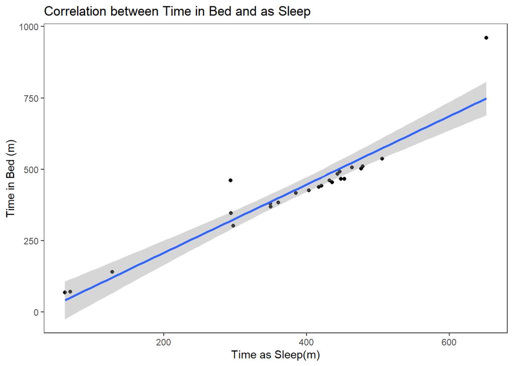

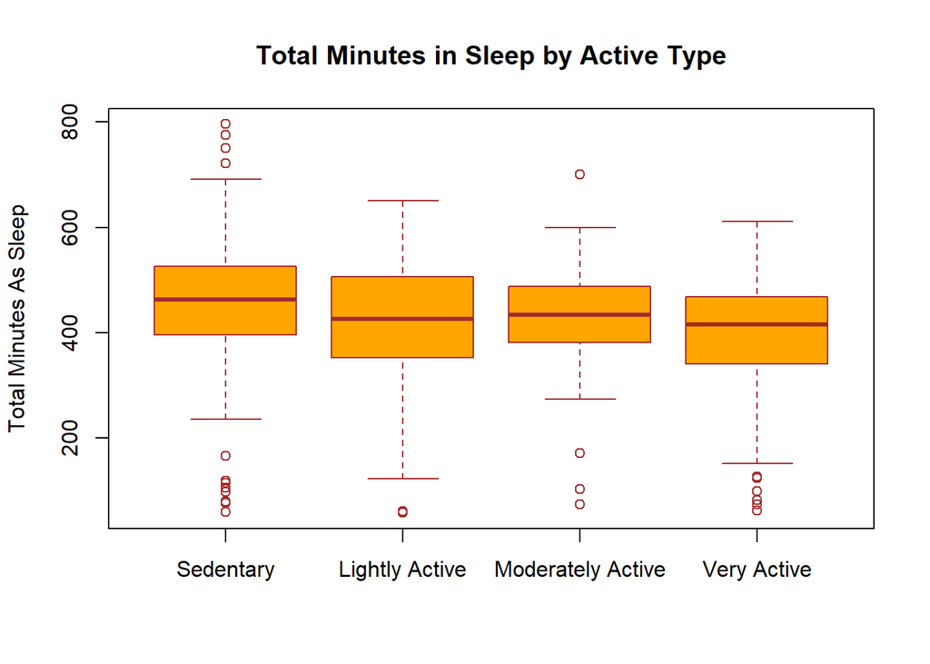

```r
boxplot(TotalMinutesAsleep~active_type,
        data=data_by_active_type,
        main="Total Minutes in Sleep by Active Type",
        xlab="",
        ylab="Total Minutes As Sleep",
        col="orange",
        border="brown"
)
```